# Julia Creek Dunnart Density Analysis

Author

Charlotte Patterson

## Project Description

The Julia Creek Dunnart (*Sminthopsis douglasi*) is an endangered small mammal found in central west Queensland, Australia. This project aims to provide the first population density and population size estimates for *S. douglasi* within a national park. Density and population size are estimated via spatially explicit capture-recapture, using live capture data collected over seven trapping sessions between 2022 and 2023.

Further details of the project methods, results, and discussion are presented in our paper entitled: “Density of a cryptic Australian small mammal: the threatened Julia Creek Dunnart (*Sminthopsis douglasi*)” Ecology and Evolution. A. H. Bakker, Patterson C.R., Mifsud G., Reside A., Fuller S., and Baker A.M.

# Load required packages

```r
library(purrr)

packages <- c("secr", "sf", "ggplot2", "dplyr")

walk(packages, require, character.only = T)
```

# Load the data

Load the capture file and the trap file. View these. Each session is a unique trapping period at one of the two sites (Scrammy - site A, Campbells - site B). Each row is a unique capture event. The ID for individual animals is in the column “ID”. The column “occasion” is the trap night for that session. The Detector is the unique ID for each trap. Some sessions caught zero individuals, these sessions are noted in the data with ID == “NONE”. Hence, the ‘No live releases’ comment in the code output.

```r
# Set order to make sure session-specific trap layouts match with sessions order at the two field sites (ordered by session name)

CH <- read.capthist("Data/captfile_zeros.txt", c("Data/trapfile_campbells_MGA2020.txt", "Data/trapfile_campbells_MGA2020.txt", "Data/trapfile_campbells_MGA2020.txt", "Data/trapfile_campbells_MGA2020.txt", "Data/trapfile_campbells_MGA2020.txt", "Data/trapfile_campbells_MGA2020.txt", "Data/trapfile_scrammy_MGA2020.txt", "Data/trapfile_scrammy_MGA2020.txt", "Data/trapfile_scrammy_MGA2020.txt", "Data/trapfile_scrammy_MGA2020.txt", "Data/trapfile_scrammy_MGA2020.txt", "Data/trapfile_scrammy_MGA2020.txt"),
                    detector = "multi")
```

```
Session campbellsfive
No live releases
Session campbellsfour
No live releases
Session campbellsthree
No live releases
```

## View trapping summary

```r
summary(CH, terse = T)
```

```
           campbellsfive campbellsfour campbellsseven campbellssix
Occasions              7             3              7            7
Detections             0             0              9           15
Animals                0             0              6            9
Detectors            100           100            100          100
           campbellsthree campbellstwo scrammyfive scrammyfour scrammyseven
Occasions               7            6           7           4            7
Detections              0            3           4           2            8
Animals                 0            3           4           1            5
Detectors             100          100         100         100          100
           scrammysix scrammythree scrammytwo
Occasions           7            7          2
Detections         28           12          2
Animals            19            9          2
Detectors         100          100        100
```

```r
# Or view full summary output
# summary(CH)
```

# Plot recaptures

```r
# Load only occasions with no zeros, just to plot recaptures

CH.no.zeros <- read.capthist("Data/captfile.txt", c("Data/trapfile_campbells_MGA2020.txt", "Data/trapfile_campbells_MGA2020.txt", "Data/trapfile_campbells_MGA2020.txt", "Data/trapfile_scrammy_MGA2020.txt", "Data/trapfile_scrammy_MGA2020.txt", "Data/trapfile_scrammy_MGA2020.txt", "Data/trapfile_scrammy_MGA2020.txt", "Data/trapfile_scrammy_MGA2020.txt", "Data/trapfile_scrammy_MGA2020.txt"), detector = "multi")
```

```
No errors found :-)
```

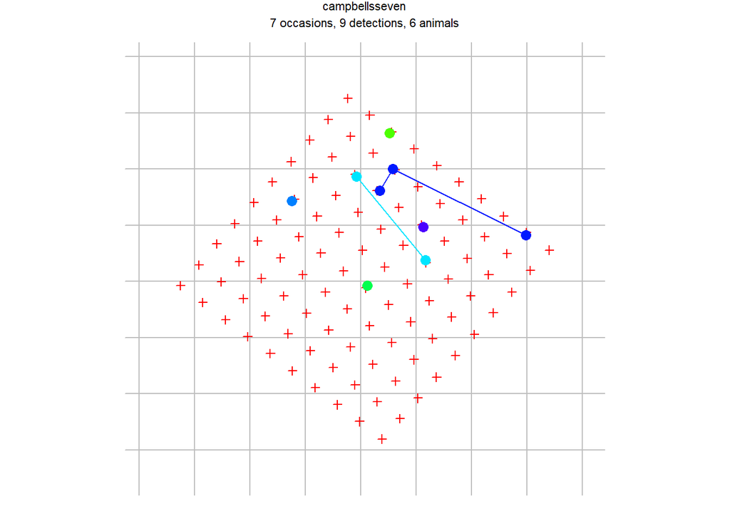

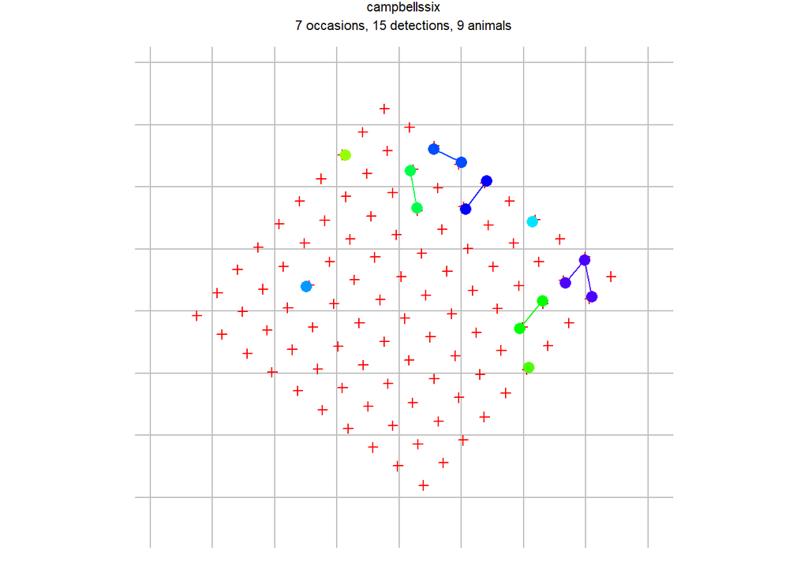

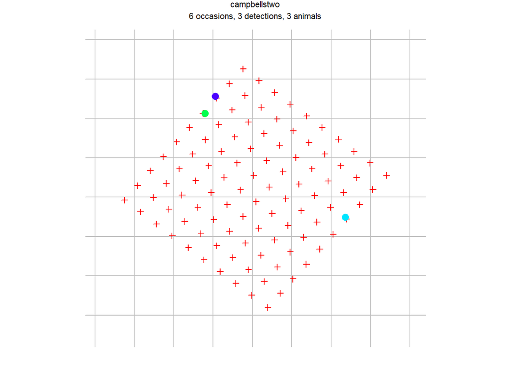

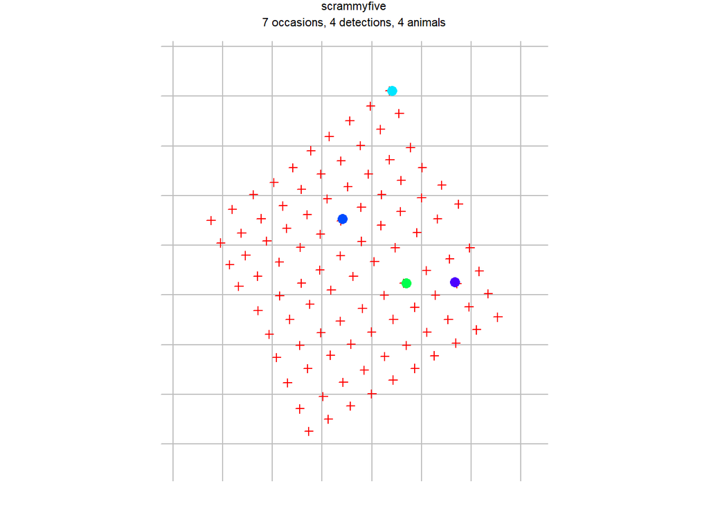

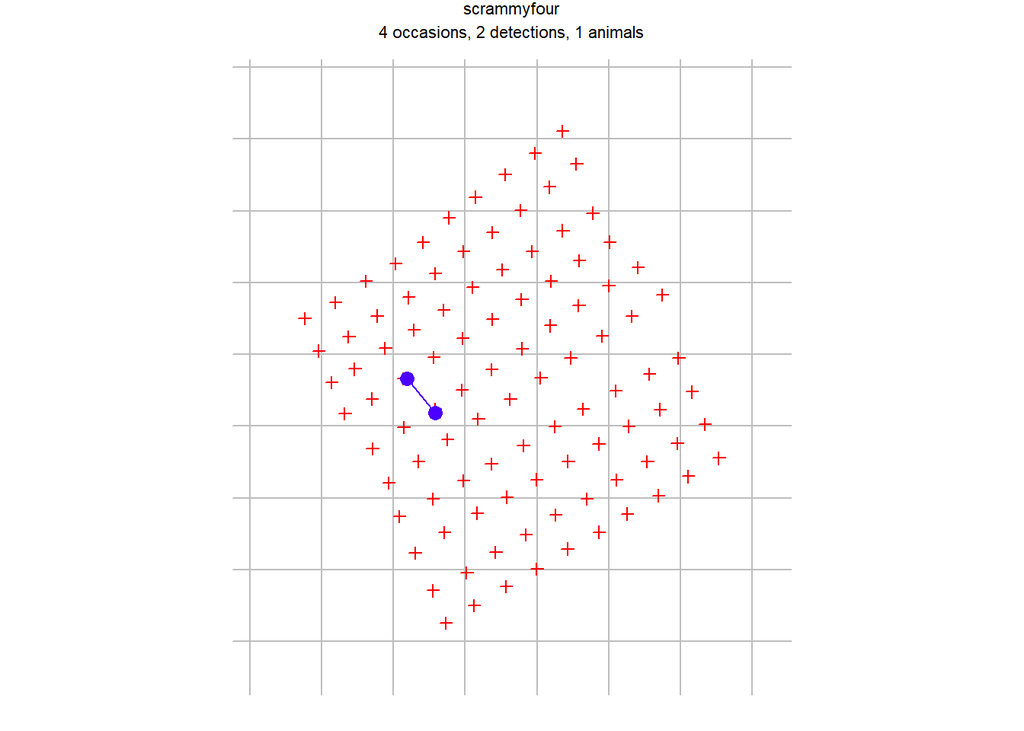

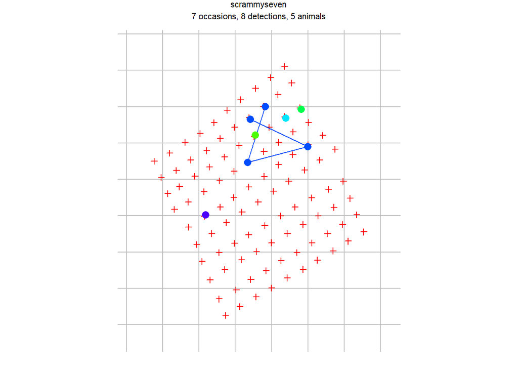

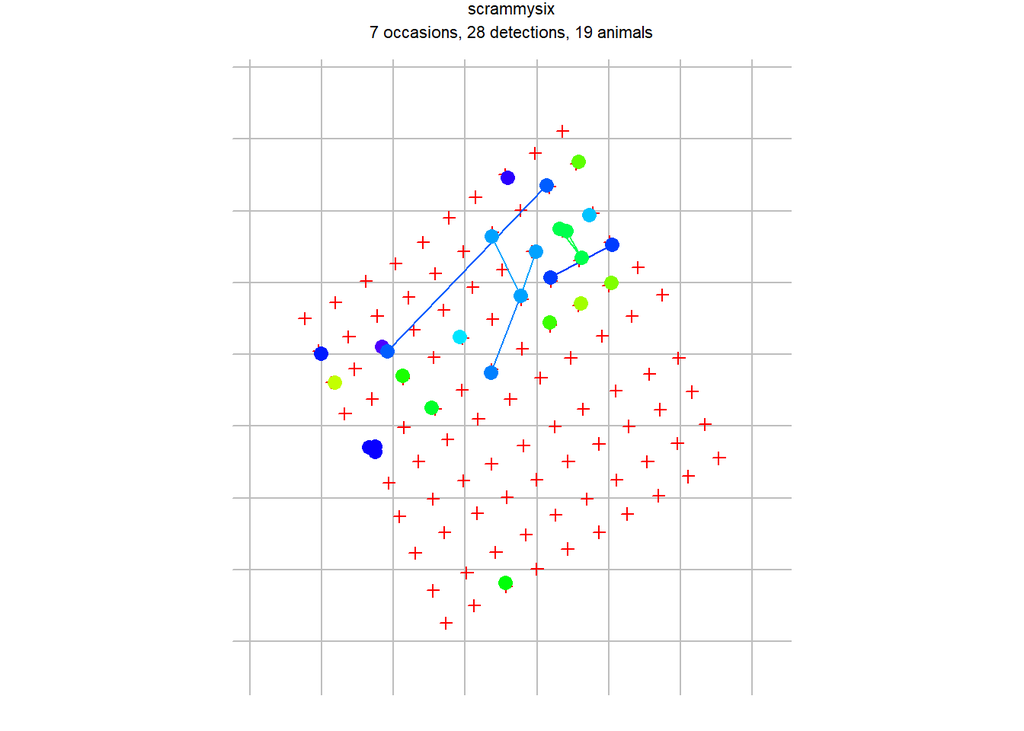

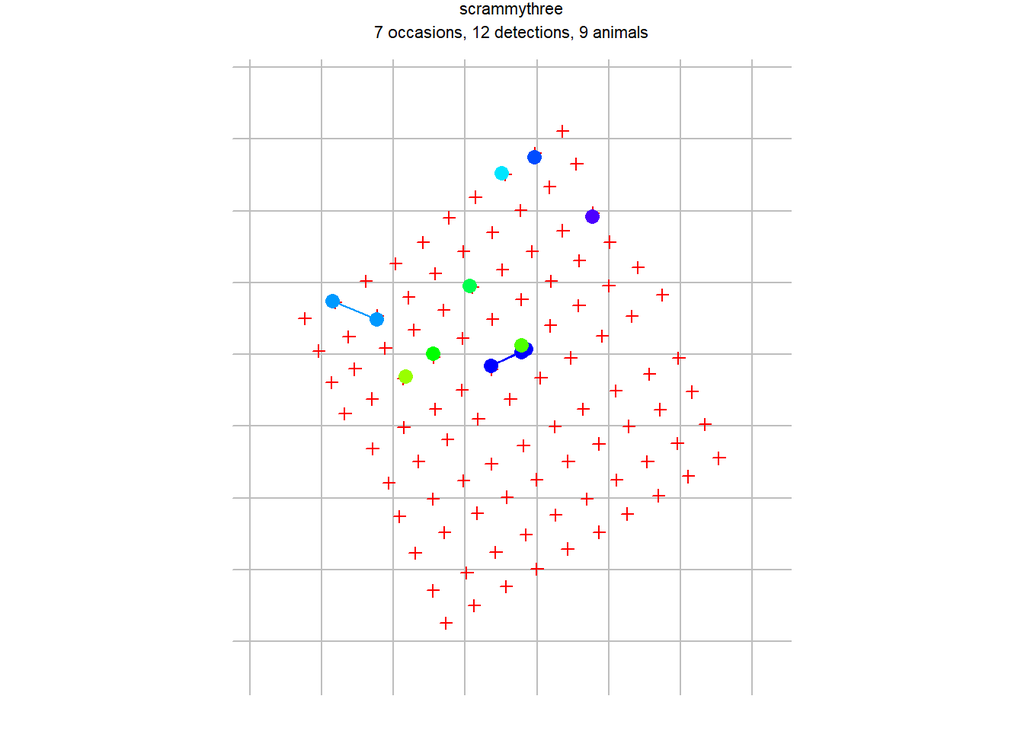

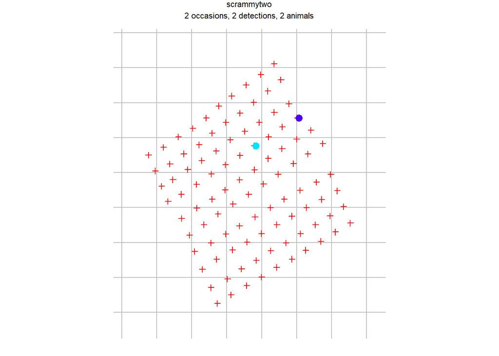

```
campbellsseven   campbellssix   campbellstwo    scrammyfive    scrammyfour
             9             15              3              4              2
  scrammyseven     scrammysix   scrammythree     scrammytwo
             8             28             12              2
```

```r
par(mar = c(1,1,2,1))
plot(CH.no.zeros, tracks = TRUE)
```

View successive trap-revealed movement distances, summarise with the median and a histogram. Observing that most individuals were showing movements > 50 m (our trap spacing) suggests that even individuals with home range centres outside of the trapping grid would have had the opportunity to be caught (Efford, 2022).

```r
m <- unlist(moves(CH))
m
```

```
campbellsseven.21 campbellsseven.22  campbellsseven.4   campbellssix.11
        261.83551          49.15844         203.51493          51.38980
  campbellssix.12    campbellssix.2    campbellssix.3    campbellssix.6
         67.85502          50.67253          49.98391          66.75001
   campbellssix.7     scrammyfour.1   scrammyseven.21   scrammyseven.22
         49.96525          61.19083         178.07939         168.17787
  scrammyseven.23     scrammysix.31     scrammysix.32      scrammysix.5
        156.93552           0.00000           0.00000          98.40969
     scrammysix.6      scrammysix.7     scrammysix.81     scrammysix.82
        320.85100         106.18599         101.69885          68.56398
   scrammysix.111    scrammysix.112   scrammythree.21   scrammythree.22
         47.38029          47.38029          51.40011          51.40011
   scrammythree.4
         61.06169
```

```r
median(m)
```

```
[1] 61.19083
```

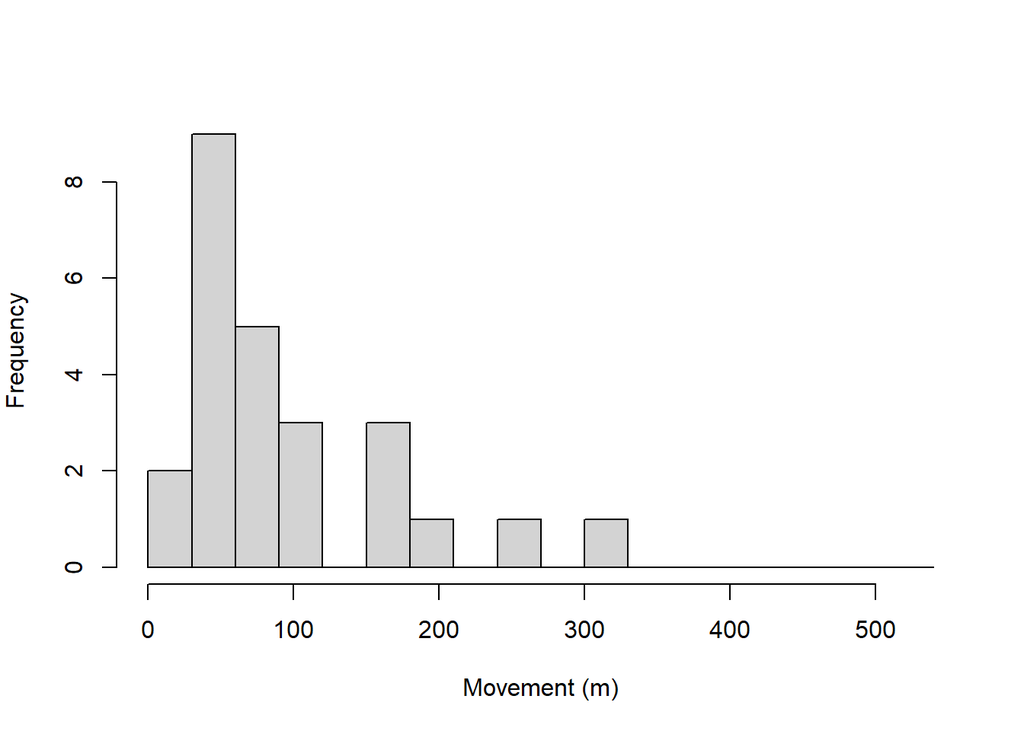

```r
par(mar = c(5,4,4,2), mgp = c(3,1,0)) # reduce margins
hist(m, breaks = seq(0, 550,30), xlab = "Movement (m)", main = "")
```

## Choosing detection function

We must check the effect of different detection function shapes. We do this by fitting models with the half-normal and exponential functions and comparing the estimated densities. We set the autoini = 4 to set our starting parameter values from a session with capture data. The default for a multi-session analysis is to take starting parameter values from the first session which doesn’t work when the session has no captures.

We also compare model fit via AICc (Akaike’s Corrected Information Criterion).

```r
# The half-normal
fit.HN <- secr.fit(CH,
                detectfn = 'HN',
                buffer = 300,
                details = list(autoini = 4),
                trace = F,
                verify = F)

# Now the exponential
fit.EX <- secr.fit (CH,
                  detectfn = 'EX',
                  buffer = 300,
                  details = list(autoini = 4),
                  trace = FALSE,
                  verify = F)

# Combine into an object of class secrlist
fits <- secrlist(HN = fit.HN, EX = fit.EX)

# Look at the density values, g0 and sigma, plus SEs
predict(fits)
```

```
$HN
$HN$`session = campbellsfive`
       link   estimate SE.estimate          lcl         ucl
D       log  0.2527833 0.049001216  0.173486273  0.36832549
g0    logit  0.0161402 0.004374708  0.009469894  0.02737899
sigma   log 68.0049301 8.301192465 53.582171275 86.30987535

$HN$`session = campbellsfour`
       link   estimate SE.estimate          lcl         ucl
D       log  0.2527833 0.049001216  0.173486273  0.36832549
g0    logit  0.0161402 0.004374708  0.009469894  0.02737899
sigma   log 68.0049301 8.301192465 53.582171275 86.30987535

$HN$`session = campbellsseven`
       link   estimate SE.estimate          lcl         ucl
D       log  0.2527833 0.049001216  0.173486273  0.36832549
g0    logit  0.0161402 0.004374708  0.009469894  0.02737899
sigma   log 68.0049301 8.301192465 53.582171275 86.30987535

$HN$`session = campbellssix`
       link   estimate SE.estimate          lcl         ucl
D       log  0.2527833 0.049001216  0.173486273  0.36832549
g0    logit  0.0161402 0.004374708  0.009469894  0.02737899
sigma   log 68.0049301 8.301192465 53.582171275 86.30987535

$HN$`session = campbellsthree`
       link   estimate SE.estimate          lcl         ucl
D       log  0.2527833 0.049001216  0.173486273  0.36832549
g0    logit  0.0161402 0.004374708  0.009469894  0.02737899
sigma   log 68.0049301 8.301192465 53.582171275 86.30987535

$HN$`session = campbellstwo`
       link   estimate SE.estimate          lcl         ucl
D       log  0.2527833 0.049001216  0.173486273  0.36832549
g0    logit  0.0161402 0.004374708  0.009469894  0.02737899
sigma   log 68.0049301 8.301192465 53.582171275 86.30987535

$HN$`session = scrammyfive`
       link   estimate SE.estimate          lcl         ucl
D       log  0.2527833 0.049001216  0.173486273  0.36832549
```

[output cut: 91 more lines]

```
D       log  0.26474242  0.05148006  0.18148383  0.38619722
g0    logit  0.05360545  0.01699061  0.02854204  0.09844724
sigma   log 36.45741884  5.63922533 26.97116777 49.28015722

$EX$`session = scrammythree`
       link    estimate SE.estimate         lcl         ucl
D       log  0.26474242  0.05148006  0.18148383  0.38619722
g0    logit  0.05360545  0.01699061  0.02854204  0.09844724
sigma   log 36.45741884  5.63922533 26.97116777 49.28015722

$EX$`session = scrammytwo`
       link    estimate SE.estimate         lcl         ucl
D       log  0.26474242  0.05148006  0.18148383  0.38619722
g0    logit  0.05360545  0.01699061  0.02854204  0.09844724
sigma   log 36.45741884  5.63922533 26.97116777 49.28015722
```

The density estimates are similar. The difference is in the detection parameters g0 and sigma.

## Plotting alternate model fits

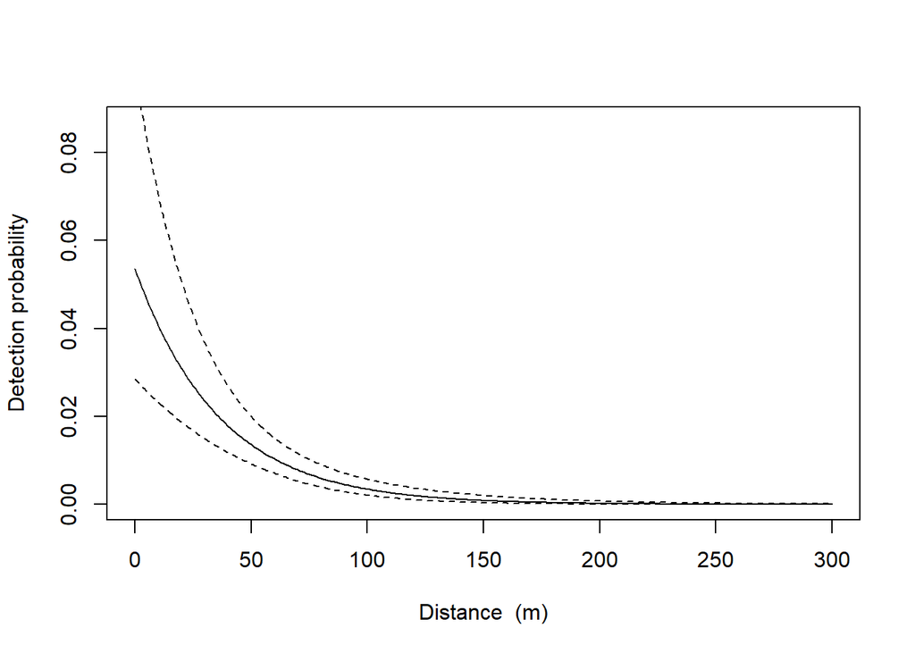

```r
plot(fit.EX, limits = T, xval = 0:300)
```

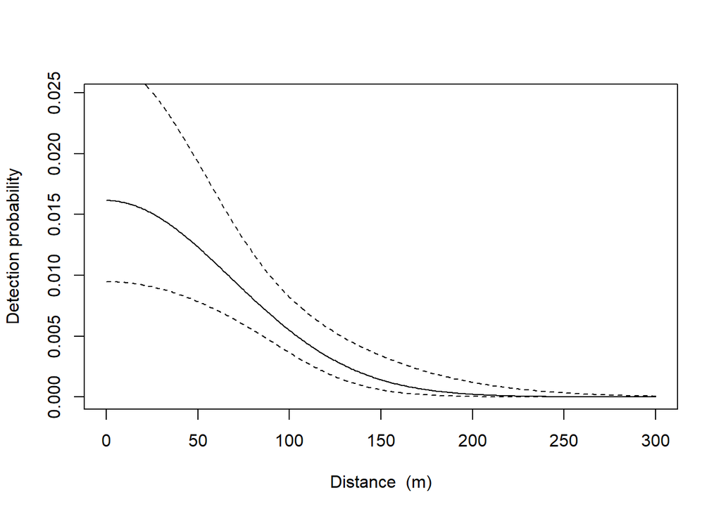

```r
plot(fit.HN, limits = T, xval = 0:300)
```

Apply AICc.

```r
AIC(fits,criterion = 'AICc')
```

```
              model    detectfn npar    logLik      AIC     AICc dAICc AICcwt
EX D~1 g0~1 sigma~1 exponential    3 -494.8180  995.636  996.081 0.000 0.9852
HN D~1 g0~1 sigma~1  halfnormal    3 -499.0163 1004.033 1004.477 8.396 0.0148
```

The most-supported model is the exponential, with an AICc weight of 0.99 and a ΔAICc from the exponential to the half-normal of 8.4.

## Choosing Buffer Width

```r
initialsigma <- RPSV(CH, CC = TRUE)
print(initialsigma)
```

```
$campbellsfive
[1] NA

$campbellsfour
[1] NA

$campbellsseven
[1] 108.4343

$campbellssix
[1] 27.85704

$campbellsthree
[1] NA

$campbellstwo
[1] NaN

$scrammyfive
[1] NaN

$scrammyfour
[1] 30.59558

$scrammyseven
[1] 72.99183

$scrammysix
[1] 62.23358

$scrammythree
[1] 24.58182

$scrammytwo
[1] NaN
```

```r
lapply(initialsigma, FUN = function(x) print(x*4))
```

```
[1] NA
[1] NA
[1] 433.7371
[1] 111.4282
[1] NA
[1] NaN
[1] NaN
[1] 122.3823
[1] 291.9673
[1] 248.9343
[1] 98.32728
[1] NaN
```

```
$campbellsfive
[1] NA

$campbellsfour
[1] NA

$campbellsseven
[1] 433.7371

$campbellssix
[1] 111.4282

$campbellsthree
[1] NA

$campbellstwo
[1] NaN

$scrammyfive
[1] NaN

$scrammyfour
[1] 122.3823

$scrammyseven
[1] 291.9673

$scrammysix
[1] 248.9343

$scrammythree
[1] 98.32728

$scrammytwo
[1] NaN
```

We check this further by plotting the decline in detection probability when we fit a simple model, and the decline in estimated density with increasing buffer width.

[figure not shown]

```r
esa.plot(fit.EX)
abline(v = 300, lty = 2, col = 'red')
```

## Fitting alternate models

We have selected a set of candidate models for comparison via AICc. The first ‘fit.EX’ is our original null model with the exponential detection function. We will compare this to a model where density varies by site ‘fit.site.D.EX’, where density and g0 vary by site ‘fit.site.D.g0.EX’, where only g0 varies by site ‘fit.site.g0.EX’, where density varies by season ‘fit.season.D.EX’, where density and g0 vary by season ‘fit.season.D.g0.EX’, and where only g0 varies by season ‘fit.season.g0.EX’.

```r
# null model
# fit.EX

# Load covariate information
covariates <- read.csv("Data/covariates.csv")

# Site models
fit.site.D.EX <- secr.fit(CH,
                    detectfn = 'EX',
                    buffer = 300,
                    model = list(D ~ site, g0 ~ 1, sigma ~1),
                    details = list(autoini = 4),
                    trace = FALSE,
                    verify = F,
                    sessioncov = covariates)

fit.site.D.g0.EX <- secr.fit(CH,
                    detectfn = 'EX',
                    buffer = 300,
                    model = list(D ~ site, g0 ~ site, sigma ~1),
                    details = list(autoini = 4),
                    trace = FALSE,
                    verify = F,
                    sessioncov = covariates)

fit.site.g0.EX <- secr.fit(CH,
                    detectfn = 'EX',
                    buffer = 300,
                    model = list(D ~ 1, g0 ~ site, sigma ~1),
                    details = list(autoini = 4),
                    trace = FALSE,
                    verify = F,
                    sessioncov = covariates)

# Season models
fit.season.D.EX <- secr.fit(CH,
                    detectfn = 'EX',
                    buffer = 300,
                    model = list(D ~ season, g0 ~ 1, sigma ~1),
                    details = list(autoini = 4),
                    trace = FALSE,
                    verify = F,
                    sessioncov = covariates)

fit.season.D.g0.EX <- secr.fit(CH,
                    detectfn = 'EX',
                    buffer = 300,
                    model = list(D ~ season, g0 ~ season, sigma ~1),
                    details = list(autoini = 4),
                    trace = FALSE,
                    verify = F,
                    sessioncov = covariates)

fit.season.g0.EX <- secr.fit(CH,
                    detectfn = 'EX',
                    buffer = 300,
                    model = list(D ~ 1, g0 ~ season, sigma ~1),
                    details = list(autoini = 4),
                    trace = FALSE,
                    verify = F,
                    sessioncov = covariates)

# Now combining to compare via AICc
fits <- secrlist(EX = fit.EX,
                 site.D = fit.site.D.EX,
                 site.D.g0 = fit.site.D.g0.EX,
                 site.g0 = fit.site.g0.EX,
                 season.D = fit.season.D.EX,
                 season.D.g0 = fit.season.D.g0.EX,
                 season.g0 = fit.season.g0.EX
                 )


AIC(fits,criterion = 'AICc')
```

```
                                 model    detectfn npar    logLik     AIC
site.D             D~site g0~1 sigma~1 exponential    4 -489.8558 987.712
site.D.g0       D~site g0~site sigma~1 exponential    5 -489.6567 989.313
season.D         D~season g0~1 sigma~1 exponential    4 -492.6841 993.368
site.g0            D~1 g0~site sigma~1 exponential    4 -492.9064 993.813
season.g0        D~1 g0~season sigma~1 exponential    4 -493.4547 994.909
EX                    D~1 g0~1 sigma~1 exponential    3 -494.8180 995.636
season.D.g0 D~season g0~season sigma~1 exponential    5 -492.6557 995.311
               AICc dAICc AICcwt
site.D      988.466 0.000 0.6485
site.D.g0   990.467 2.001 0.2385
season.D    994.123 5.657 0.0383
site.g0     994.568 6.102 0.0307
season.g0   995.664 7.198 0.0177
EX          996.081 7.615 0.0144
season.D.g0 996.465 7.999 0.0119
```

It appears that the model for site-specific density has the greatest support, with an AICc weight of 0.65 and a ΔAICc from the site-specific density model to the site-specific density and g0 of 2.001. We will use this model to estimate density and population size.

We will examine the coefficients and the density, g0, and sigma estimates for the site-specific density model, but will also look at the site-specific density and g0 model to check if there’s any large difference between the outputs of these since they were close in the AICc.

```r
summary(fit.site.D.EX)
```

```
$versiontime
[1] "4.6.4, run 10:59:40 15 May 2024, elapsed 54.26 s"

$capthist
           campbellsfive campbellsfour campbellsseven campbellssix
Occasions              7             3              7            7
Detections             0             0              9           15
Animals                0             0              6            9
Detectors            100           100            100          100
Moves                  0             0              3            6
Animals2               0             0              2            5
           campbellsthree campbellstwo scrammyfive scrammyfour scrammyseven
Occasions               7            6           7           4            7
Detections              0            3           4           2            8
Animals                 0            3           4           1            5
Detectors             100          100         100         100          100
Moves                   0            0           0           1            3
Animals2                0            0           0           1            1
           scrammysix scrammythree scrammytwo
Occasions           7            7          2
Detections         28           12          2
Animals            19            9          2
Detectors         100          100        100
Moves               7            3          0
Animals2            5            2          0

$trapsummary
$trapsummary$campbellsfive
Object class       traps
Detector type      multi
Detector number    100
Average spacing    49.28565 m
x-range            94374.94 95040.33 m
y-range            7506019 7506626 m

$trapsummary$campbellsfour
Object class       traps
Detector type      multi
Detector number    100
Average spacing    49.28565 m
```

[output cut: 179 more lines]

```
D       log  0.37883524  0.08184001  0.24926290  0.57576215
g0    logit  0.05311187  0.01685618  0.02825817  0.09762879
sigma   log 36.45359050  5.64341248 26.96152835 49.28742330

$predicted$`session = scrammythree, site = scrammy`
       link    estimate SE.estimate         lcl         ucl
D       log  0.37883524  0.08184001  0.24926290  0.57576215
g0    logit  0.05311187  0.01685618  0.02825817  0.09762879
sigma   log 36.45359050  5.64341248 26.96152835 49.28742330

$predicted$`session = scrammytwo, site = scrammy`
       link    estimate SE.estimate         lcl         ucl
D       log  0.37883524  0.08184001  0.24926290  0.57576215
g0    logit  0.05311187  0.01685618  0.02825817  0.09762879
sigma   log 36.45359050  5.64341248 26.96152835 49.28742330
```

```r
summary(fit.site.D.g0.EX)
```

```
$versiontime
[1] "4.6.4, run 11:00:34 15 May 2024, elapsed 113.55 s"

$capthist
           campbellsfive campbellsfour campbellsseven campbellssix
Occasions              7             3              7            7
Detections             0             0              9           15
Animals                0             0              6            9
Detectors            100           100            100          100
Moves                  0             0              3            6
Animals2               0             0              2            5
           campbellsthree campbellstwo scrammyfive scrammyfour scrammyseven
Occasions               7            6           7           4            7
Detections              0            3           4           2            8
Animals                 0            3           4           1            5
Detectors             100          100         100         100          100
Moves                   0            0           0           1            3
Animals2                0            0           0           1            1
           scrammysix scrammythree scrammytwo
Occasions           7            7          2
Detections         28           12          2
Animals            19            9          2
Detectors         100          100        100
Moves               7            3          0
Animals2            5            2          0

$trapsummary
$trapsummary$campbellsfive
Object class       traps
Detector type      multi
Detector number    100
Average spacing    49.28565 m
x-range            94374.94 95040.33 m
y-range            7506019 7506626 m

$trapsummary$campbellsfour
Object class       traps
Detector type      multi
Detector number    100
Average spacing    49.28565 m
```

[output cut: 180 more lines]

```
D       log  0.40199372  0.09747580  0.2516287  0.64221199
g0    logit  0.04880677  0.01703585  0.0243857  0.09529549
sigma   log 36.43728971  5.63051150 26.9642552 49.23837395

$predicted$`session = scrammythree, site = scrammy`
       link    estimate SE.estimate        lcl         ucl
D       log  0.40199372  0.09747580  0.2516287  0.64221199
g0    logit  0.04880677  0.01703585  0.0243857  0.09529549
sigma   log 36.43728971  5.63051150 26.9642552 49.23837395

$predicted$`session = scrammytwo, site = scrammy`
       link    estimate SE.estimate        lcl         ucl
D       log  0.40199372  0.09747580  0.2516287  0.64221199
g0    logit  0.04880677  0.01703585  0.0243857  0.09529549
sigma   log 36.43728971  5.63051150 26.9642552 49.23837395
```

The positive coefficient for site indicates an increase in density at Scrammy (Site A). The density estimate is also higher there. The two models mostly give similar estimates, so we are confident that our results change very little with the two models.

## Population size estimate

First load the habitat layer and transform it to the same projection as the trap file.

```r
# Load habitat layer
habitat_layer <- read_sf("Data/AOI_DISSOLVED.shp")

# Transform so it has the same projection as the trap file
habitat_layer <- st_transform(habitat_layer, crs = 7855)
```

Then use the ‘region.N’ function to estimate the population size within the habitat layer.

```r
region.N(fit.site.D.EX,
         region = habitat_layer
         )
```

```
$campbellsfive
    estimate SE.estimate      lcl      ucl n
E.N 922.5333    252.7997 544.4255 1563.240 0
R.N 919.2241    250.9684 543.4866 1554.726 0

$campbellsfour
    estimate SE.estimate      lcl      ucl n
E.N 922.5333    252.7997 544.4255 1563.240 0
R.N 920.7570    250.9684 544.8528 1556.005 0

$campbellsseven
    estimate SE.estimate      lcl      ucl n
E.N 922.5333    252.7997 544.4255 1563.240 6
R.N 925.2241    250.9684 549.4866 1560.726 6

$campbellssix
    estimate SE.estimate      lcl      ucl n
E.N 922.5333    252.7997 544.4255 1563.240 9
R.N 928.2241    250.9684 552.4866 1563.726 9

$campbellsthree
    estimate SE.estimate      lcl      ucl n
E.N 922.5333    252.7997 544.4255 1563.240 0
R.N 919.2241    250.9684 543.4866 1554.726 0

$campbellstwo
    estimate SE.estimate      lcl      ucl n
E.N 922.5333    252.7997 544.4255 1563.240 3
R.N 922.5416    250.9684 546.7696 1557.991 3

$scrammyfive
    estimate SE.estimate      lcl      ucl n
E.N 2175.955    464.7230 1438.403 3291.694 4
R.N 2172.029    462.3759 1437.984 3281.828 4

$scrammyfour
    estimate SE.estimate      lcl      ucl n
E.N 2175.955    464.7230 1438.403 3291.694 1
R.N 2171.639    462.3759 1437.407 3281.178 1

$scrammyseven
    estimate SE.estimate      lcl      ucl n
E.N 2175.955    464.7230 1438.403 3291.694 5
R.N 2173.029    462.3759 1438.984 3282.828 5

$scrammysix
    estimate SE.estimate      lcl      ucl  n
E.N 2175.955    464.7230 1438.403 3291.694 19
R.N 2187.029    462.3759 1452.984 3296.828 19

$scrammythree
    estimate SE.estimate      lcl      ucl n
E.N 2175.955    464.7230 1438.403 3291.694 9
R.N 2177.029    462.3759 1442.984 3286.828 9

$scrammytwo
    estimate SE.estimate      lcl      ucl n
E.N 2175.955    464.7230 1438.403 3291.694 2
R.N 2174.969    462.3759 1440.572 3284.278 2
```

## Calculate the average population size

The above result outputs two estimates, one based on the Site A (Scrammy) density estimate and one based on the Site B (Campbell) density estimate.

We standardise the mean population size by weighting each estimate by the inverse of the variance.

```r
SiteA <- 2175.953
SiteA_SE <- 462.3759

SiteB <- 922.5362
SiteB_SE <- 252.8003

wA <- 1/(SiteA_SE^2)
wB <- 1/(SiteB_SE^2)

N <- (wA*SiteA + wB*SiteB)/(wA + wB)

SE <- sqrt(1/(wA + wB))
CI <- 1.96*SE

print(paste0("Mean Population size is ", round(N,2), " with a standard error of ", round(SE,2), "and a 95% CI of ", round(N - CI,2), " to ", round(N + CI,2)))
```

```
[1] "Mean Population size is 1210.99 with a standard error of 221.81and a 95% CI of 776.24 to 1645.74"
```

# References

Borchers, D. L., and M. G. Efford. 2008. Spatially explicit maximum likelihood methods for capture– recapture studies. Biometrics 64:377–385.

Efford, M. 2022. A tutorial on fitting spatially explicit capture–recapture models in secr. https://www.otago.ac.nz/density/pdfs/secr-tutorial.pdf.

Otis, D. L., K. P. Burnham, G. C. White, and D. R. Anderson. 1978. Statistical inference from capture data on closed animal populations. Wildlife Monographs:3–135.